# Trabalho 4 slides

## Analisando dados do Wikileaks

### Alice Duarte Scarpa

## Obtendo os dados

Os dados foram obtidos a partir de uma tabela PostgreSQL com todos os cabos diplomáticos baixada de: http://file.wikileaks.org/torrent/cable_db_full.7z.torrent

Para gerar um banco de dados a partir do arquivo fornecido:

```
psql cable < cb_db_full.sql
```

#### O banco tem quantas linhas?

```
base=> SELECT COUNT(*) FROM cable;
 count
--------
251287
(1 row)
```

#### Quais são as colunas desse banco de dados?

```
base=> \d cable

                                       Table "public.cable"
     Column     |            Type             |                     Modifiers
----------------+-----------------------------+----------------------------------------------------
 id             | integer                     | not null default nextval('cable_id_seq'::regclass)
 date           | timestamp without time zone |
 refid          | character varying           |
 classification | character varying           |
 origin         | character varying           |
 destination    | text                        |
 header         | text                        |
 content        | text                        |
Indexes:
    "cable_pkey" PRIMARY KEY, btree (id)
```

As colunas são id, date, refid, classification, origin, destination, header e content.

#### Uma linha do banco

```
base=> SELECT * FROM cable LIMIT 1;
```

O resultado foi omitido por ser muito longo.

#### Exportando os dados

Nesse trabalho vamos lidar apenas com os meta-dados presentes, i.e.: id, date, refid, classification, origin e destination. 'header' e 'content' abrem muitos caminhos interessantes para a exploração que fogem ao escopo desse trabalho.

Para exportar os dados que vamos usar para um csv (note, o código abaixo é muito lento e depende de o banco de dados já ter sido criado no seu sistema. Não recomendo que seja rodado nesse notebook)

```python
#!/usr/bin/python
# -*- coding: utf-8 -*-
import csv
import psycopg2
import sys

con = None

# Conectando ao banco de dados
con = psycopg2.connect("dbname='base' user='alice_scarpa'")
cur = con.cursor()
cur.execute("SELECT * FROM cable")
col_names = [cn[0] for cn in cur.description]

# Escrevendo um csv com os dados que vamos usar
with open('export.csv', 'w') as f:
    writer = csv.writer(f)
    writer.writerow(col_names[0:6])
    for i in range(251288):
        row = cur.fetchone()
        writer.writerow(row[0:6])

# Fechando a conexao
con.close()
```

O mesmo resultado pode ser obtido com uma linha de sql:

```
base=> \copy (SELECT id, date, classification, refid, origin, destination FROM cable) TO 'export.csv' CSV HEADER;
```

## Preprocessamento

```python
#!/usr/bin/python
# -*- coding: utf-8 -*-
%matplotlib inline

import pandas as pd
import matplotlib.pyplot as plt

pd.set_option('display.mpl_style', 'default') # Deixando os gráficos mais bonitos
plt.rcParams['figure.figsize'] = (15, 5)
plt.rcParams['font.family'] = 'sans-serif'
```

```python
# Carregando os dados e vendo as primeiras linhas
cabos = pd.read_csv('export.csv', parse_dates=['date'], dayfirst=True, index_col='id')
print len(cabos)
cabos[0:5]
```

```
251287
```

| id | date | classification | refid | origin | destination |
| --- | --- | --- | --- | --- | --- |
| 1 | 1966-12-28 | UNCLASSIFIED | 66BUENOSAIRES2481 | Embassy Buenos Aires | 66STATE106206 |
| 2 | 1972-02-25 | UNCLASSIFIED | 72TEHRAN1164 | Embassy Tehran | 72MOSCOW1603\|72TEHRAN1091\|72TEHRAN263 |
| 3 | 1972-03-09 | UNCLASSIFIED | 72TEHRAN1381 | Embassy Tehran | NaN |
| 4 | 1972-08-10 | UNCLASSIFIED | 72TEHRAN4789 | Embassy Tehran | 72TEHRAN3312 |
| 5 | 1972-08-22 | UNCLASSIFIED | 72TEHRAN5055 | Embassy Tehran | 72TEHRAN4887 |

### Coisas a limpar:

- Um telegrama pode ter muitos destinos, queremos considerar cada destino individualmente
- refid e cada destino sempre contém dígitos que não queremos (são formalidades do governo americano que não nos interessam para esse trabalho)
- Algumas linhas contém campos vazios ('NaN' no Pandas); queremos ignorá-las

Vamos preprocessar o csv com um script antes de carregar para o pandas.

```python
import csv
import re

with open('export.csv', 'r') as entrada:
    with open('dados_processados.csv', 'w') as saida:
        csvreader = csv.reader(entrada)
        csvwriter = csv.writer(saida)
        flag = True
        for linha in csvreader:
            # A primeira linha é especial
            if flag:
                csvwriter.writerow(linha)
                flag = False
                continue
            destinos = linha[-1].split('|')
            for destino in destinos:
                # Removendo dígitos de refid e destino
                nova_linha = linha[:3] + [re.sub("\d+", "", linha[3])] + [linha[4]] + [re.sub("\d+", "", destino)]
                # Escrevendo linhas que têm todos os campos não-vazios
                if '' not in nova_linha:
                    csvwriter.writerow(nova_linha)
```

```python
# Carregando os dados novamente e vendo as primeiras linhas
cabos = pd.read_csv('dados_processados.csv', parse_dates=['date'], dayfirst=True, index_col='id')
cabos = cabos.drop_duplicates()
print len(cabos)
cabos[0:5]
```

```
136730
```

| id | date | classification | refid | origin | destination |
| --- | --- | --- | --- | --- | --- |
| 1 | 1966-12-28 | UNCLASSIFIED | BUENOSAIRES | Embassy Buenos Aires | STATE |
| 2 | 1972-02-25 | UNCLASSIFIED | TEHRAN | Embassy Tehran | MOSCOW |
| 2 | 1972-02-25 | UNCLASSIFIED | TEHRAN | Embassy Tehran | TEHRAN |
| 4 | 1972-08-10 | UNCLASSIFIED | TEHRAN | Embassy Tehran | TEHRAN |
| 5 | 1972-08-22 | UNCLASSIFIED | TEHRAN | Embassy Tehran | TEHRAN |

```python
# Adicionando uma coluna de 1s para facilitar a manipulação
cabos.loc[:,'total'] = 1
```

## Analisando datas

```python
cabos[['date', 'total']].groupby('date').aggregate(sum).plot()
```

[output not shown]

[output not shown]

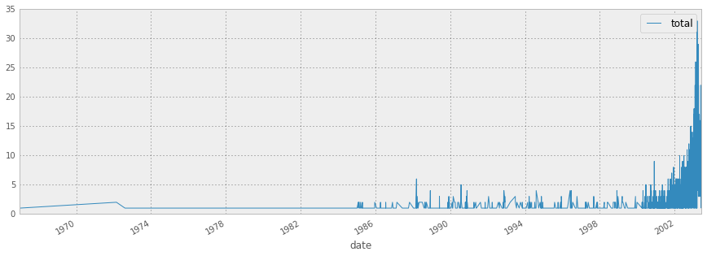

```python
# Olhando slices dos dados
cabos[['date', 'total']].groupby('date').aggregate(sum)[:1200].plot()
```

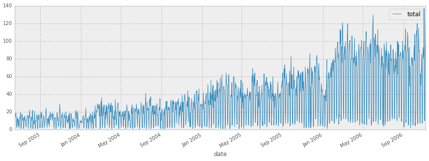

```python
cabos[['date', 'total']].groupby('date').aggregate(sum)[1200:2400].plot()
```

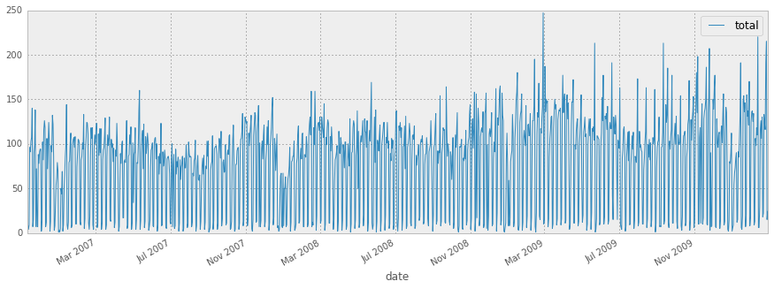

```python
cabos[['date', 'total']].groupby('date').aggregate(sum)[2400:].plot()
```

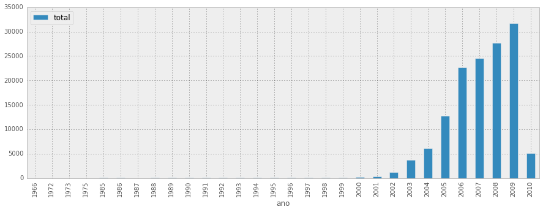

```python
# Organizando por ano
# Adicionando uma chave 'ano'
cabos.loc[:,'ano'] = cabos.date.dt.year
cabos[['ano', 'total']].groupby('ano').aggregate(sum).plot(kind='bar')
```

```python
# Adicionando a chave 'dia da semana'
cabos.loc[:,'dia da semana'] = cabos.date.dt.weekday
cabos[0:5]
```

| id | date | classification | refid | origin | destination | total | ano | dia da semana |
| --- | --- | --- | --- | --- | --- | --- | --- | --- |
| 1 | 1966-12-28 | UNCLASSIFIED | BUENOSAIRES | Embassy Buenos Aires | STATE | 1 | 1966 | 2 |
| 2 | 1972-02-25 | UNCLASSIFIED | TEHRAN | Embassy Tehran | MOSCOW | 1 | 1972 | 4 |
| 2 | 1972-02-25 | UNCLASSIFIED | TEHRAN | Embassy Tehran | TEHRAN | 1 | 1972 | 4 |
| 4 | 1972-08-10 | UNCLASSIFIED | TEHRAN | Embassy Tehran | TEHRAN | 1 | 1972 | 3 |
| 5 | 1972-08-22 | UNCLASSIFIED | TEHRAN | Embassy Tehran | TEHRAN | 1 | 1972 | 1 |

```python
telegramas_por_dia = cabos[['total', 'dia da semana']].groupby('dia da semana').aggregate(sum)
telegramas_por_dia.index = ['Segunda', 'Terça', 'Quarta', 'Quinta', 'Sexta', 'Sábado', 'Domingo']
telegramas_por_dia
```

|  | total |
| --- | --- |
| Segunda | 22335 |
| Terça | 25351 |
| Quarta | 27307 |
| Quinta | 26663 |
| Sexta | 29706 |
| Sábado | 2033 |
| Domingo | 3335 |

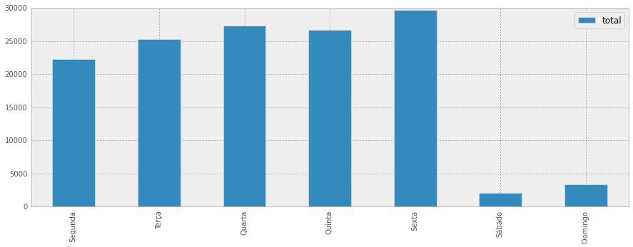

```python
telegramas_por_dia.plot(kind='bar')
```

## Classificação

```python
telegramas_por_classificacao = cabos[['total', 'classification']].groupby('classification').aggregate(sum)
telegramas_por_classificacao
```

| classification | total |
| --- | --- |
| CONFIDENTIAL | 55601 |
| CONFIDENTIAL//NOFORN | 3284 |
| SECRET | 8122 |
| SECRET//NOFORN | 3379 |
| UNCLASSIFIED | 32806 |
| UNCLASSIFIED//FOR OFFICIAL USE ONLY | 33538 |

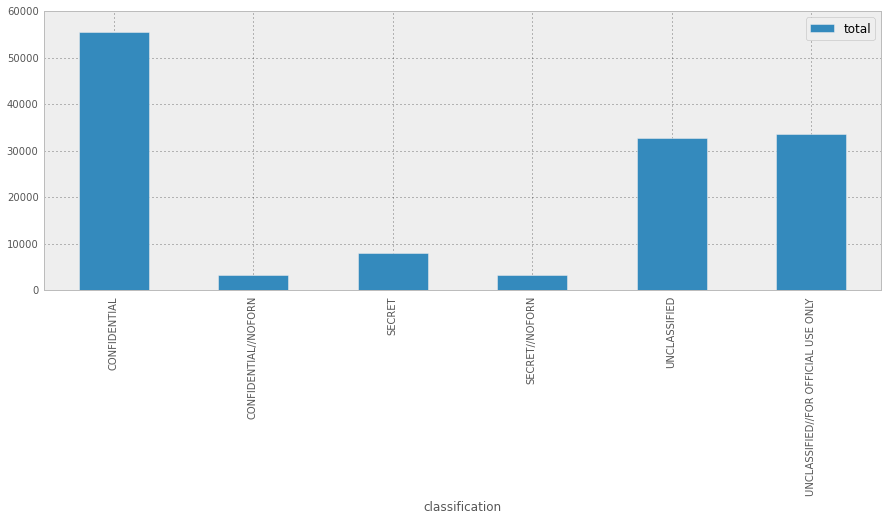

```python
telegramas_por_classificacao.plot(kind='bar')
```

NOFORN é abreviação para 'no foreign nationals' e significa que o telegrama não pode ser divulgado para pessoas que não são cidadãs dos EUA

## Conexões

```python
# O primeiro passo é montar um grafo
import collections
import csv

grafo = collections.defaultdict(int)
codigo_para_nome = {}
with open('dados_processados.csv', 'r') as entrada:
    leitor = csv.reader(entrada)
    next(leitor, None)
    for linha in leitor:
        grafo[(linha[3], linha[5])] += 1
        codigo_para_nome[linha[3]] = linha[4].replace('Embassy ', '').replace('Consulate ', '').replace('REO ', '').replace('USEU ','')

print len(grafo)
```

```
5449
```

```python
# Qual a conexão mais forte?

maiores = sorted(list(grafo.iteritems()), key=lambda x: x[1], reverse=True)
print maiores[0:5]
```

```
[(('BAGHDAD', 'BAGHDAD'), 4548), (('STATE', 'STATE'), 3787), (('AMMAN', 'AMMAN'), 3568), (('ANKARA', 'ANKARA'), 3545), (('KUWAIT', 'KUWAIT'), 3230)]
```

Então as conexões mais forte são comunicações internas dentro de uma embaixada.

Vamos ver com lugares diferentes:

```python
grafo_externo = {key: value for key, value in grafo.iteritems() if key[0] != key[1]}

maiores_externos = sorted(list(grafo_externo.iteritems()), key=lambda x: x[1], reverse=True)
print maiores_externos[0:5]
```

```
[(('TAIPEI', 'AITTAIPEI'), 1421), (('THEHAGUE', 'STATE'), 1276), (('MADRID', 'STATE'), 1164), (('ANKARA', 'STATE'), 1152), (('ROME', 'STATE'), 1105)]
```

```python
print len(codigo_para_nome)
# Vendo as primeiras chaves
for key in codigo_para_nome.keys()[0:5]:
    print key, ':', codigo_para_nome[key]
```

```
340
GEORGETOWN : Georgetown
VLADIVOSTOK : Vladivostok
RIYADH : Riyadh
GUATEMLA : Guatemala
BUSSELS : Brussels
```

Queremos plotar esses pontos em um mapa. Para isso vamos precisar encontrar a latitude e longitude desses pontos

```python
import json
from geopy.geocoders import Nominatim

def acha_coordenadas(lugar):
    with open('coordenadas.json', 'r') as f:
        coord = json.load(f)
    if lugar in coord:
        return coord[lugar]

    geolocator = Nominatim()
    loc = geolocator.geocode(lugar)
    try:
        coord[lugar] = loc.latitude, loc.longitude
    except:
        coord[lugar] = None

    with open('coordenadas.json', 'w') as f:
        json.dump(coord, f, sort_keys=True, indent=4, separators=(',', ': '))

    return coord[lugar]

acha_coordenadas('Rio de Janeiro')
```

```
[-22.9110137, -43.2093727]
```

```python
coordenadas = {}
for codigo, cidade in codigo_para_nome.iteritems():
    coordenadas[codigo] = acha_coordenadas(cidade)
print len(coordenadas)

coordenadas = {key: value for key,value in coordenadas.iteritems() if value is not None}
print len(coordenadas)
```

```
340
323
```

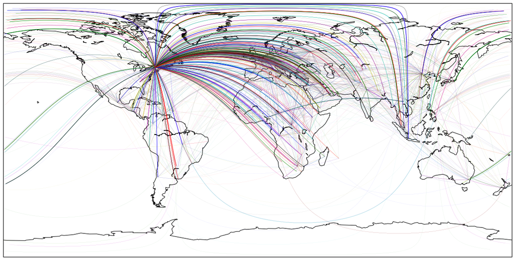

```python
from mpl_toolkits.basemap import Basemap
import numpy as np
import matplotlib.pyplot
import math

%matplotlib inline
plt.rcParams['figure.figsize'] = (20, 20)

m = Basemap(projection='cyl', lon_0=0, resolution='c')

m.drawcoastlines()


for origem, destino in grafo.keys():
    if origem not in coordenadas or destino not in coordenadas:
        continue
    lat1, lon1 = coordenadas[origem]
    lat2, lon2 = coordenadas[destino]
    line, = m.drawgreatcircle(lon2, lat2, lon1, lat1, lw=0.04*math.sqrt(grafo[(origem, destino)]))

    # A versão do Basemap disponível por apt-get tem um defeito que gera caminhos estranhos
    # O código abaixo (retirado do Stack Overflow) conserta esse defeito
    p = line.get_path()
    cut_point = np.where(np.abs(np.diff(p.vertices[:, 0])) > 200)[0]
    if cut_point:
        cut_point = cut_point[0]

        new_verts = np.concatenate(
                                   [p.vertices[:cut_point, :],
                                    [[np.nan, np.nan]],
                                    p.vertices[cut_point+1:, :]]
                                   )
        p.codes = None
        p.vertices = new_verts



plt.show()
```